# Set_9

Alexander Williams

2024-10-16

# Anova for Factorial Experiments

factorial experiments are very important, used everywhere

in one-way ANOVA, what we were looking at, it’s a way to compare means of J different samples with only one factor changing. what if the different sample populations are changing two or more factors?

each combination of factor levels is a sample of $n$ measurements, $n$ maybe be referred to as the degree of replication

our objective is to measure the response variable over these different factors and levels, and how the different factors might interact.

## Example: Farm animal diets

two factors: diet and supplement, measuring weight after 6 weeks Diet: barley, oat, wheat Supplement: agrimore, control, supergain, supersupp

```r
weights <- read.table(file='~/Documents/uni/STAT359/data/growth.csv',
                      header=TRUE, sep=",")
attach(weights)
names(weights)
```

```
## [1] "supplement" "diet"       "gain"
```

```r
kable(weights)
```

| supplement | diet | gain |
| --- | --- | --- |
| supergain | wheat | 17.37125 |
| supergain | wheat | 16.81489 |
| supergain | wheat | 18.08184 |
| supergain | wheat | 15.78175 |
| control | wheat | 17.70656 |
| control | wheat | 18.22717 |
| control | wheat | 16.08650 |
| control | wheat | 17.60184 |
| supersupp | wheat | 20.78861 |
| supersupp | wheat | 20.00858 |
| supersupp | wheat | 19.30287 |
| supersupp | wheat | 18.57330 |
| agrimore | wheat | 19.54688 |
| agrimore | wheat | 17.96440 |
| agrimore | wheat | 21.43738 |
| agrimore | wheat | 19.60763 |
| supergain | oats | 19.36092 |
| supergain | oats | 20.64938 |
| supergain | oats | 19.60615 |
| supergain | oats | 19.03557 |
| control | oats | 21.56473 |
| control | oats | 20.25976 |
| control | oats | 19.20455 |
| control | oats | 20.94562 |
| supersupp | oats | 21.14743 |
| supersupp | oats | 23.00609 |
| supersupp | oats | 21.90279 |
| supersupp | oats | 21.38462 |
| agrimore | oats | 23.58744 |
| agrimore | oats | 22.31517 |
| agrimore | oats | 22.37653 |
| agrimore | oats | 24.91439 |
| supergain | barley | 23.82942 |
| supergain | barley | 23.75688 |
| supergain | barley | 21.34873 |
| supergain | barley | 20.92947 |
| control | barley | 24.69354 |
| control | barley | 24.32013 |
| control | barley | 22.02811 |
| control | barley | 22.14482 |
| supersupp | barley | 24.62988 |
| supersupp | barley | 23.08774 |
| supersupp | barley | 27.79490 |
| supersupp | barley | 26.78869 |
| agrimore | barley | 26.04248 |
| agrimore | barley | 25.28337 |
| agrimore | barley | 25.03889 |
| agrimore | barley | 29.02916 |

this dataset has four measurements for each of the combinations. Lets create a matrix to show mean weight gain for each combination

```r
# apply mean to the vector gain, separately for each factor in the list
mean.matrix <- tapply(gain,list(diet, supplement),mean)
mean.matrix
```

```
##        agrimore  control supergain supersupp
## barley 26.34848 23.29665  22.46612  25.57530
## oats   23.29838 20.49366  19.66300  21.86023
## wheat  19.63907 17.40552  17.01243  19.66834
```

lets plot this data

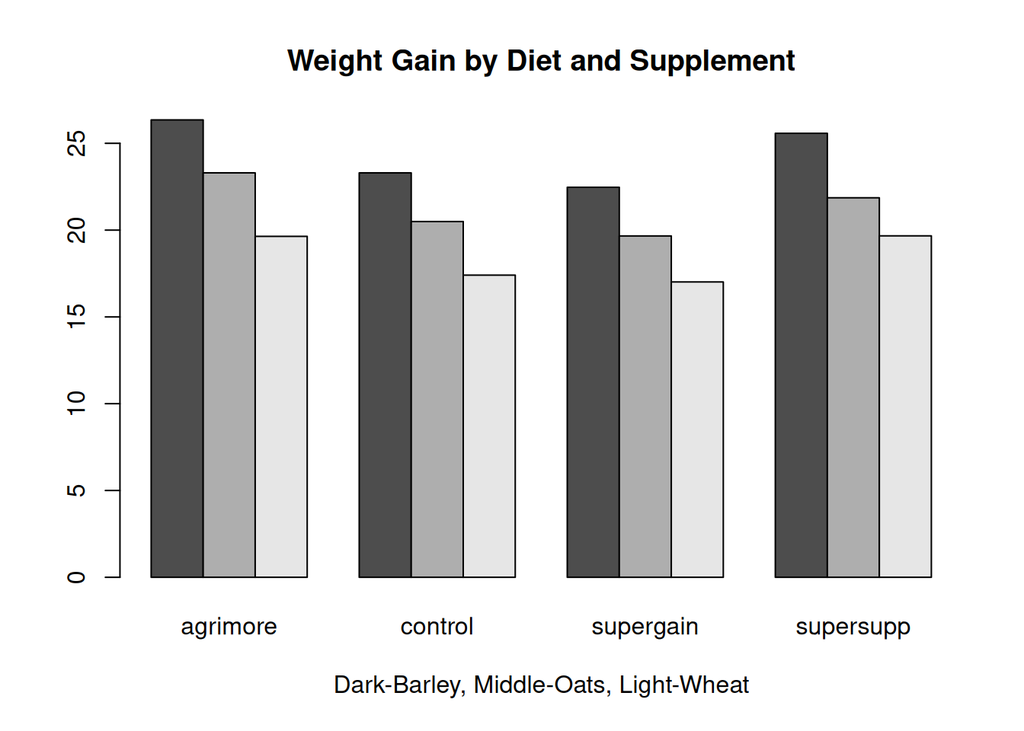

```r
barplot(mean.matrix, beside=TRUE,
        xlab="Dark-Barley, Middle-Oats, Light-Wheat")
title("Weight Gain by Diet and Supplement")
```

```r
# legend
labels<-levels(diet)
shade<-c(0.2,0.6,0.9)
# legend(x=3.,y=26,labels,gray(shade),cex=0.7)
```

There’s definitely a pattern with diet, barley always has most weight gain, followed by oats, and then wheat. Patterns with the supplement are a lot less clear.

we can fit an ANOVA that considers how the means vary. Symbolically
$$\text{Gain ~ Diet +
Supplement}$$

a more complex model takes into account how different factors respond to each other
$$\text{Gain}\sim\text{Diet +
Supplement + Diet x Supplement}$$

this is a factorial model

```r
model<-aov(gain~diet*supplement)
summary(model)
```

```
##                 Df Sum Sq Mean Sq F value   Pr(>F)
## diet             2 287.17  143.59   83.52 3.00e-14 ***
## supplement       3  91.88   30.63   17.82 2.95e-07 ***
## diet:supplement  6   3.41    0.57    0.33    0.917
## Residuals       36  61.89    1.72
## ---
## Signif. codes:  0 '***' 0.001 '**' 0.01 '*' 0.05 '.' 0.1 ' ' 1
```

Note the F-value in diet:supplement. The null hypothesis is that diet has no effect on supplement, and supplement has no effect on diet. with such a high p-value, the null hypothesis is very likely, so there is no interaction between diet and supplement.

Now, look at supplement. Null hypothesis is that supplement does not effect weight. absolutely tiny p-value, that’s evidence against the null hypothesis. Supplement does play a role in wight gain.

Same thing in the diet row, extremely small p-value so it does play a role in weight.

We can also compute p-values by hand

```r
# pf(f-value, degrees of freedom)
1-pf(83.52, 2, 36) # diet
```

```
## [1] 2.997602e-14
```

```r
1-pf(17.82,3,36) # supplement
```

```
## [1] 2.943114e-07
```

```r
1-pf(0.33,6,36) # diet:supplement
```

```
## [1] 0.9167143
```

Since there’s no interaction between diet and supplement, we can remove that from the model to get a more accurate result

```r
model2 <- aov(gain~diet+supplement)
summary(model2)
```

```
##             Df Sum Sq Mean Sq F value   Pr(>F)
## diet         2 287.17  143.59   92.36 4.20e-16 ***
## supplement   3  91.88   30.63   19.70 3.98e-08 ***
## Residuals   42  65.30    1.55
## ---
## Signif. codes:  0 '***' 0.001 '**' 0.01 '*' 0.05 '.' 0.1 ' ' 1
```

With this more accurate model, it’s even more confident that diet and supplement effect weight. Lets visualize this with error bars

remember that error range is calculated with:
$$LSD=t_{2(n-1),\alpha/2}\sqrt{2}\hat{\sigma}/\sqrt{n}$$
Test level alpha, and the $\sqrt2$ is because it’s based on standard error of difference between two means.

### Aside: multiple testing error

when testing multiple things, each one with an $\alpha$ chance of error, the chance of a type-1 error compounds. As we do more tests, the odds of a type-1 error increases at a rate of $1- (1-\alpha)^m$, given m tests, increasing exponentially. How do we deal with this?

One way of controlling this is by setting alpha to control the probability of making at least one error over *all* the tests, so instead of using $\alpha$, we use $\alpha/m$. This means we run the tests with a much smaller alpha than usual, which can lead to a much more conservative result
$$LSD=t_{2(n-1),\frac{\alpha}{2m}}\sqrt{2}\hat{\sigma}/\sqrt{n}$$
Note the new degrees of freedom for the t-distribution that accounts for the number of tests to make.

This is the simplest way to handle multiple error, but not necessarily the best.

Since have $4*3=12$ different categories, the way to compare two bars is $_{12}C_2=66$, meaning $m=66$

```r
LSD<-qt(1-0.0004,6)*1.24/sqrt(2)
LSD
```

```
## [1] 5.45095
```

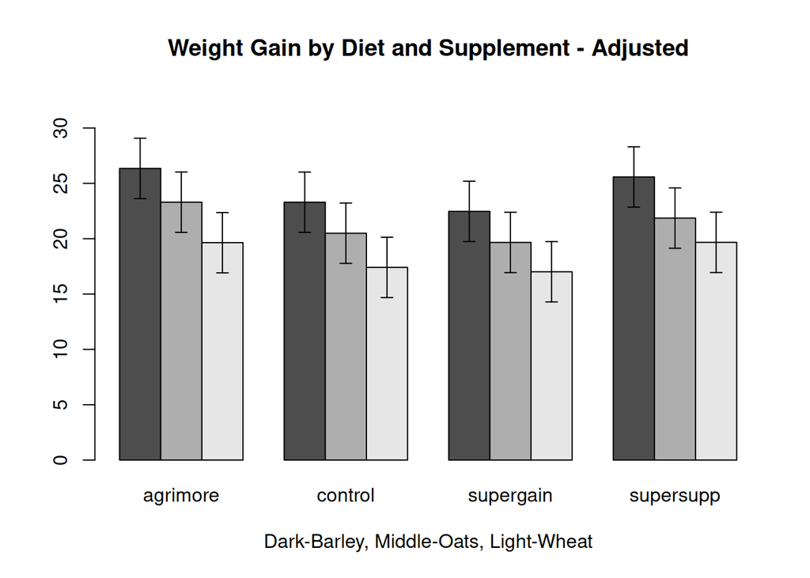

```r
barplot(tapply(gain,list(diet,supplement),mean),beside=TRUE,xlab="Dark-Barley, Middle-Oats, Light-Wheat",ylim=c(0,33))
title("Weight Gain by Diet and Supplement - Adjusted")
x<-as.vector(barplot(tapply(gain,list(diet,supplement),mean),beside=TRUE,ylim=c(0,32),plot=F))
y<-as.vector(tapply(gain,list(diet,supplement),mean))
z<-rep(LSD/2,length(x))
for (i in 1:length(x))
{
  arrows(x[i],y[i]-z[i],x[i],y[i]+z[i],length=0.05,code=3,angle=90)
}
```

Very large error bars here. We could say, barley and wheat do not have the same impact on weight, but that’s about it. We can’t say that barley and oats are different, or oats and wheat are different.

We can examine the estimated effect sizes and their standard error

```r
model<-lm(gain~diet+supplement)
summary(model)
```

```
##
## Call:
## lm(formula = gain ~ diet + supplement)
##
## Residuals:
##      Min       1Q   Median       3Q      Max
## -2.30792 -0.85929 -0.07713  0.92052  2.90615
##
## Coefficients:
##                     Estimate Std. Error t value Pr(>|t|)
## (Intercept)          26.1230     0.4408  59.258  < 2e-16 ***
## dietoats             -3.0928     0.4408  -7.016 1.38e-08 ***
## dietwheat            -5.9903     0.4408 -13.589  < 2e-16 ***
## supplementcontrol    -2.6967     0.5090  -5.298 4.03e-06 ***
## supplementsupergain  -3.3815     0.5090  -6.643 4.72e-08 ***
## supplementsupersupp  -0.7274     0.5090  -1.429     0.16
## ---
## Signif. codes:  0 '***' 0.001 '**' 0.01 '*' 0.05 '.' 0.1 ' ' 1
##
## Residual standard error: 1.247 on 42 degrees of freedom
## Multiple R-squared:  0.8531, Adjusted R-squared:  0.8356
## F-statistic: 48.76 on 5 and 42 DF,  p-value: < 2.2e-16
```

We can subtract their estimates to get their difference. Going by p-values, we can reject the null hypothesis for everything other than the supersupp supplement.

since the effects of supergain and control seem the same, can we put those in one category? What about supersupp and agrimore?

We can, but why do we want to? It should only be if it makes what you want to analyze more clear

```r
supp2<-factor(supplement)
levels(supp2)
```

```
## [1] "agrimore"  "control"   "supergain" "supersupp"
```

```r
levels(supp2)[c(1,4)]<-"best"
levels(supp2)[c(2,3)]<-"worst"
levels(supp2)
```

```
## [1] "best"  "worst"
```

it’s okay to do this, but be careful. Only do it if you expect it to have a result, don’t do it blindly.

```r
model2<-lm(gain~diet+supp2)
anova(model,model2)
```

```
## Analysis of Variance Table
##
## Model 1: gain ~ diet + supplement
## Model 2: gain ~ diet + supp2
##   Res.Df    RSS Df Sum of Sq      F Pr(>F)
## 1     42 65.296
## 2     44 71.284 -2   -5.9876 1.9257 0.1584
```

```r
F.ratio<-((71.284 - 65.296)/2)/(65.296/42)
F.ratio
```

```
## [1] 1.925815
```

```r
p.value<-1-pf(F.ratio,2,42)
p.value
```

```
## [1] 0.1584108
```

Here, we can see that the sub-model is just as good as the larger model. Still, this is not always the answer, be very careful doing this is the real world. Best only do it to better represent something you physically want to do in the real world